# R Notebook

# Libraries

```r
library(tidytext)
library(janeaustenr)
library(textdata)
```

# MVP

## 1) Find the most common words in both Pride & Prejudice and Sense & Sensibility

| id | text |
| --- | --- |
| 1 | PRIDE AND PREJUDICE |
| 2 |  |
| 3 | By Jane Austen |
| 4 |  |
| 5 |  |
| 6 |  |
| 7 | Chapter 1 |
| 8 |  |
| 9 |  |
| 10 | It is a truth universally acknowledged, that a single man in possession |

[output cut: 990 more lines]

```r
pride_book %>%
  count(words, sort = TRUE)
```

| words | n |
| --- | --- |
| the | 4331 |
| to | 4162 |
| of | 3610 |
| and | 3585 |
| her | 2203 |
| i | 2065 |
| a | 1954 |
| in | 1880 |
| was | 1843 |
| she | 1695 |

[output cut: 990 more lines]

```r
sense_book %>%
  count(words, sort = TRUE)
```

| words | n |
| --- | --- |
| to | 4116 |
| the | 4105 |
| of | 3571 |
| and | 3490 |
| her | 2543 |
| a | 2092 |
| i | 1998 |
| in | 1979 |
| was | 1861 |
| it | 1755 |

[output cut: 990 more lines]

Top 10 in Sense and Sensibility 1) to 2) the 3) of 4) and 5) her 6) a 7) i 8) in 9) was 10) it

Top 10 in Pride and Prejudice 1) the 2) to 3) of 4) and 5) her 6) i 7) a 8) in 9) was 10) she

Pretty much all stop words!

## 2) Find the most common words in both Pride & Prejudice and Sense & Sensibility, not including stop words.

```r
pride_book %>%
  anti_join(stop_words, by = c("words" = "word")) %>%
  count(words, sort = TRUE)
```

| words | n |
| --- | --- |
| elizabeth | 597 |
| darcy | 373 |
| bennet | 294 |
| miss | 283 |
| jane | 264 |
| bingley | 257 |
| time | 203 |
| lady | 183 |
| sister | 180 |
| wickham | 162 |

[output cut: 990 more lines]

```r
sense_book %>%
  anti_join(stop_words, by = c("words" = "word")) %>%
  count(words, sort = TRUE)
```

| words | n |
| --- | --- |
| elinor | 623 |
| marianne | 492 |
| time | 239 |
| dashwood | 231 |
| sister | 229 |
| edward | 220 |
| mother | 213 |
| miss | 210 |
| jennings | 199 |
| willoughby | 181 |

[output cut: 990 more lines]

Top 10 in Sense and Sensibility w/o stop words 1) Elinor 2) Marianne 3) Time 4) Dashwood 5) Sister 6) Edward 7) Mother 8) Miss 9) Jennings 10) Willoughby

Top 10 in Pride and Prejudice w/o stop words 1) Elizabeth 2) Darcy 3) Bennet 4) Miss 5) Jane 6) Bingley 7) Time 8) Lady 9) Sister 10) Wickham

## 3) Find the most common sentiment words in both Pride & Prejudice and Sense & Sensibility.

```r
pride_book %>%
  anti_join(stop_words, by = c("words" = "word")) %>%
  inner_join(get_sentiments("bing"), by = c("words" = "word")) %>%
  filter(words != "miss") %>% #take out miss b/c its used v frequently as a title and will impact results
  count(sentiment, words, sort = TRUE)
```

| sentiment | words | n |
| --- | --- | --- |
| positive | love | 92 |
| positive | pleasure | 92 |
| positive | happy | 83 |
| positive | happiness | 72 |
| positive | affection | 58 |
| positive | regard | 49 |
| negative | object | 48 |
| positive | pride | 48 |
| positive | perfectly | 47 |
| negative | scarcely | 45 |

[output cut: 990 more lines]

```r
sense_book %>%
  anti_join(stop_words, by = c("words" = "word")) %>%
  inner_join(get_sentiments("bing"), by = c("words" = "word")) %>%
  filter(words != "miss") %>% #take out miss b/c its used v frequently as a title and will impact results
  count(sentiment, words, sort = TRUE)
```

| sentiment | words | n |
| --- | --- | --- |
| positive | happy | 100 |
| positive | affection | 79 |
| positive | love | 77 |
| negative | poor | 71 |
| positive | pleasure | 67 |
| positive | happiness | 66 |
| positive | comfort | 63 |
| positive | regard | 50 |
| negative | doubt | 46 |
| positive | glad | 44 |

[output cut: 990 more lines]

Top sentiment words in Sense and Sensibility 1) happy - positive 2) affection - positive 3) love - positive 4) poor - negative 5) pleasure - positive 6) happiness - positive 7) comfort - positive 8) regard - positive 9) doubt - negative 10) glad - positive

Top sentiment words in Pride and Prejudice 1) love - positive 2) pleasure - positive 3) happy - positive 4) happiness - positive 5) affection - positive 6) regard - positive 7) object - negative 8) pride - positive (interesting cause this isn’t considered a positive attribute in the book) 9) perfectly - positive 10) scarcely - negative

# Extension

## 1) Can you create a plot which visualises the differences between the books?

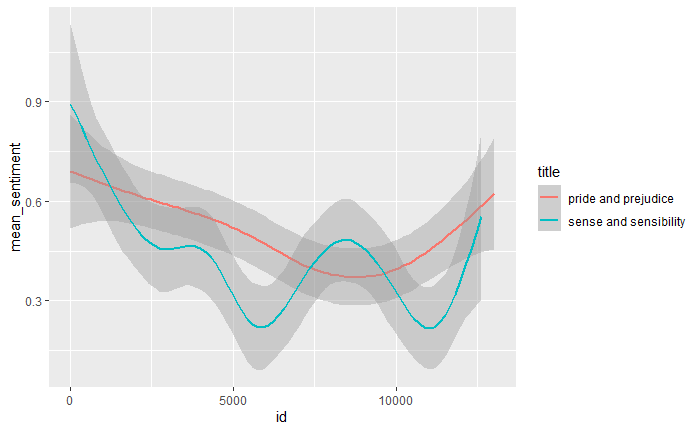

```r
book_sentiments %>%
  group_by(title, id) %>%
  summarise(mean_sentiment = mean(value)) %>%
ggplot(aes(x = id,
           y = mean_sentiment,
           colour = title)) +
  #geom_point(alpha = 0.2) +
  geom_smooth()
```

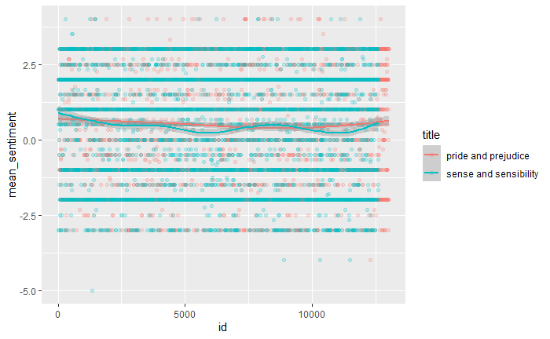

```r
book_sentiments %>%
  group_by(title, id) %>%
  summarise(mean_sentiment = mean(value)) %>%
ggplot(aes(x = id,
           y = mean_sentiment,
           colour = title)) +
  geom_point(alpha = 0.2) +
  geom_smooth()
```

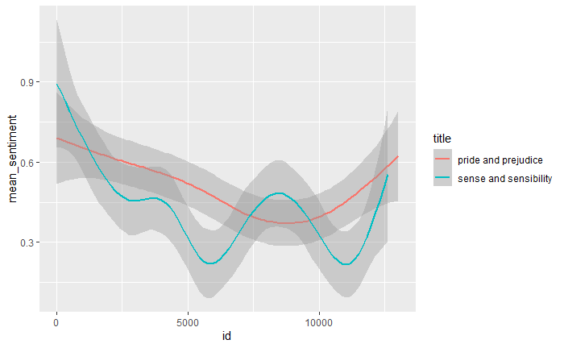

```r
book_sentiments %>%
  group_by(title, id) %>%
  summarise(mean_sentiment = mean(value)) %>%
ggplot(aes(x = id,
           y = mean_sentiment,
           colour = title)) +
  #geom_point(alpha = 0.2) +
  geom_smooth()
```

When you look at the second one without the points, you can see that sense and sensibility looks to have lower lows than pride and prejudice as well as a positive “hump” in the middle. Without revealing any spoilers, I do think that this reflects the comparative narrative flow of the two books.